# Reproducible Research, Project 1

Poul Kristensen

October 30, 2018

### Load packages and data

```r
library(ggplot2)
library(plyr)

steps <- read.csv('activity.csv')
summary(steps)
```

```
##      steps                date          interval
##  Min.   :  0.00   2012-10-01:  288   Min.   :   0.0
##  1st Qu.:  0.00   2012-10-02:  288   1st Qu.: 588.8
##  Median :  0.00   2012-10-03:  288   Median :1177.5
##  Mean   : 37.38   2012-10-04:  288   Mean   :1177.5
##  3rd Qu.: 12.00   2012-10-05:  288   3rd Qu.:1766.2
##  Max.   :806.00   2012-10-06:  288   Max.   :2355.0
##  NA's   :2304     (Other)   :15840
```

Get the total number of days and steps in sample, and calculate the mean number of steps per day:

```r
Ndays <- length(unique(steps$date))
Nsteps <- sum(steps$steps[!is.na(steps$steps)])
Meansteps <- Nsteps / Ndays
print(Ndays)
```

```
## [1] 61
```

```r
print(Nsteps)
```

```
## [1] 570608
```

```r
print(Meansteps)
```

```
## [1] 9354.23
```

### Perform aggregations

Use the ddply function to aggregate steps by day:

```r
stepsbyday <- ddply(steps, .(date), summarize, countbyday = sum(steps, na.rm = TRUE) )
```

Create a histogram of steps per day:

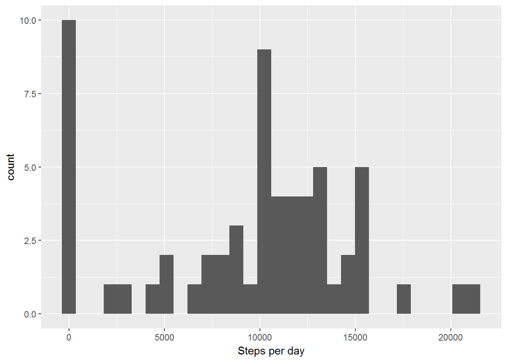

```r
qplot(stepsbyday$countbyday, geom="histogram", xlab = "Steps per day")
```

Calculate and report the mean and median of steps per day:

```r
summary(stepsbyday$countbyday)
```

```
##    Min. 1st Qu.  Median    Mean 3rd Qu.    Max.
##       0    6778   10395    9354   12811   21194
```

Calculate the average number of steps by 5-minute interval within the day, across all days, then plot the time series:

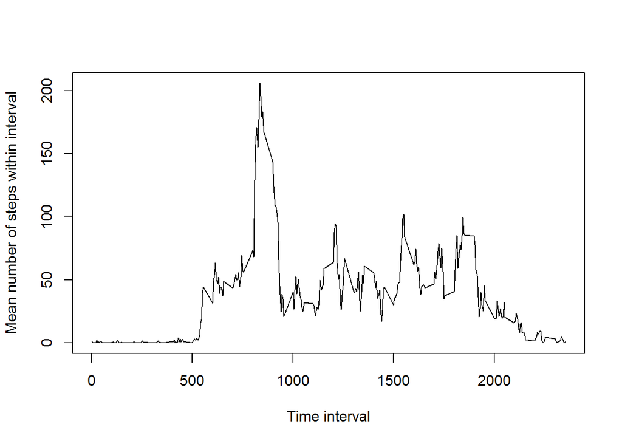

```r
byinterval <- ddply(steps[!is.na(steps$steps),], .(interval), summarize, meansteps = mean(steps))
plot(unique(steps$interval), byinterval$meansteps, type="l", xlab="Time interval",
    ylab="Mean number of steps within interval")
```

Find and print the 5-minute interval with the highest average number of steps:

```r
i <- which(max(byinterval$meansteps) == byinterval$meansteps)
print(byinterval$interval[i])
```

```
## [1] 835
```

Calculate and print the total number of missing values:

```r
Nmissing <- sum(is.na(steps$steps))
print(Nmissing)
```

```
## [1] 2304
```

Replace missing values for steps by the average for that 5-minute interval across days:

```r
itoimpute <- is.na(steps$steps)          #identify missing values
stepsNew <- steps
stepsNew$stepsImputed <- steps$steps

for (i in 1:length(itoimpute)) {
  if (itoimpute[i] == TRUE) {
    stepsNew$stepsImputed[i] <- mean(steps$steps[!is.na(steps$steps) & steps$interval == steps$interval[i]], rm.na = TRUE)
    }
}
```

Again, calculate the total number of steps per day, using the ddply function, but now in the new dataset with imputed values:

```r
stepsbydayNew <- ddply(stepsNew, .(date), summarize, countbyday = sum(stepsImputed, na.rm = TRUE) )
```

Display histogram of steps per day:

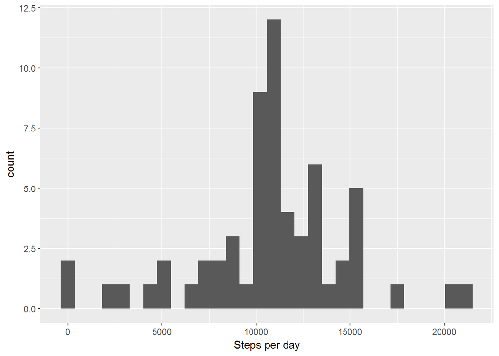

```r
qplot(stepsbydayNew$countbyday, geom="histogram", xlab = "Steps per day")
```

Calculate and display the mean and median of steps per day in the new dataset:

```r
summary(stepsbydayNew$countbyday)
```

```
##    Min. 1st Qu.  Median    Mean 3rd Qu.    Max.
##      41    9819   10766   10766   12811   21194
```

Convert date to proper date format and create “weekday”/“weekend” factor variable:

```r
steps$date2 <- as.Date(steps$date, format = "%Y-%m-%d")
steps$dayofweek <- weekdays(steps$date2)
steps$WEornot[steps$dayofweek == "Saturday" | steps$dayofweek == "Sunday"] = "weekend"
steps$WEornot[is.na(steps$WEornot)] = "weekday"
steps$WEornot <- as.factor(steps$WEornot)
```

Calculate the average number of steps by time interval for weekdays and weekends, then create panel plot for weekdays and weekends:

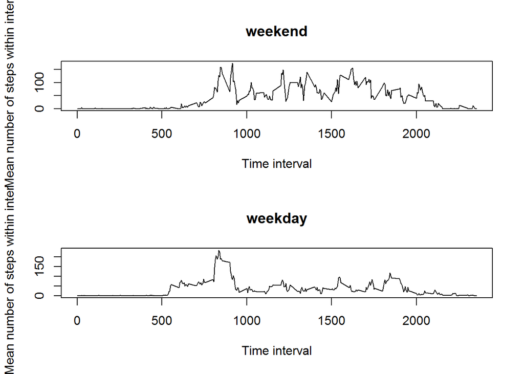

```r
byinterval <- ddply(steps[!is.na(steps$steps),], .(interval, WEornot), summarize, meansteps = mean(steps))

par(mfrow = c(2,1))
plot(byinterval$interval[byinterval$WEornot == "weekend"], byinterval$meansteps[byinterval$WEornot == "weekend"], type="l", main = "weekend", xlab="Time interval",     ylab="Mean number of steps within interval")
plot(byinterval$interval[byinterval$WEornot == "weekday"], byinterval$meansteps[byinterval$WEornot == "weekday"], type="l", main = "weekday", xlab="Time interval",     ylab="Mean number of steps within interval")
```